# Searching in podcast collection

```julia
using SimilaritySearch, SimSearchManifoldLearning, TextSearch, CodecZlib, JSON, DataFrames, Plots, StatsBase, DataFrames, Clustering, Markdown, Latexify
using Downloads: download
```

This example is about searching in a caption/subtitle collection, i.e., looking for passages in audiobooks, youtube videos, conferences, podcasts, etc. The audio should be translated with a speech to text model, i.e., Whisper of OpenAI.

Having a WebVTT set of files we need to load the corpus. The files we are using as dataset are WebVTT subtitles, which can be readed with the following code, note that this code is not part of the example and can be ignored.

```julia
mutable struct EntryVTT
    type::Symbol
    name::String
    tbegin::String
    tend::String
    data::Vector{String}
end

function webvtt!(filename, idfile, D)
    L = []
    B = nothing

    open(filename) do f
        lineno = 0
        while !eof(f)
            line = readline(f)
            lineno += 1
            if line == "WEBVTT"
                B = EntryVTT(:WEBVTT, "", "", "", String[])
                push!(L, B)
                continue
            end

            n = length(line)
            if n == 0 # flush
                if B.type === :caption
                    for caption in B.data
                        push!(D, (; idfile, B.name, B.tbegin, B.tend, caption))
                    end
                end
                B = nothing
                continue
            end

            if B === nothing
                m = match(r"^NOTE (.*)", line)
                if m !== nothing
                    B = EntryVTT(:NOTE, "", "", "", String[])
                    push!(L, B)
                    if length(m.captures[1]) > 0
                        push!(B.data, m.captures[1])
                    end

                    continue
                end

                if "REGION" == line
                    B = EntryVTT(:REGION, "", "", "", String[])
                    push!(L, B)
                    continue
                end

                if occursin("-->", line)
                    tbegin, tend = split(line)[[1, 3]]
                    B = EntryVTT(:caption, "", tbegin, tend, String[])
                    continue
                end

                B = EntryVTT(:caption, line, "", "", String[])
                push!(L, B)
            else
                if occursin("-->", line)
                    B.tbegin, B.tend = split(line)[[1, 3]]
                    continue
                end
                push!(B.data, line) # appends to the last
            end
        end
    end

    B !== nothing && push!(L, B)
    L, D
end
```

Now, we load the dataset

```julia
podcasts = sort!(readdir("/home/sadit/sites/SimilaritySearchDemos/podcast-vtt/", join=true))
```

```julia
D = DataFrame(idfile=String[], name=String[], tbegin=String[], tend=String[], caption=String[])

for filename in podcasts
    webvtt!(filename, basename(filename), D)
end

D
```

21013×5 DataFrame

20988 rows omitted

| Row | idfile String | name String | tbegin String | tend String | caption String |
| --- | --- | --- | --- | --- | --- |
| 1 | tres-patines-y-la-tremenda-corte_0000.vtt |  | 00:00.000 | 00:11.000 | Audiencia pública, el tremendo juez de la tremenda corte va a resolver un tremendo caso. |
| 2 | tres-patines-y-la-tremenda-corte_0000.vtt |  | 00:11.000 | 00:13.000 | Buenas noches, secretario. |
| 3 | tres-patines-y-la-tremenda-corte_0000.vtt |  | 00:15.000 | 00:18.000 | Buenas noches, señor juez. ¿Cómo se siente hoy? |
| 4 | tres-patines-y-la-tremenda-corte_0000.vtt |  | 00:18.000 | 00:25.000 | Campana. Hoy me siento panetela. De manera que vamos a ver si acabamos pronto que esta noche me voy de rumba. |
| 5 | tres-patines-y-la-tremenda-corte_0000.vtt |  | 00:25.000 | 00:27.000 | No me digas. ¿Se va usted de rumba? |
| 6 | tres-patines-y-la-tremenda-corte_0000.vtt |  | 00:27.000 | 00:30.000 | Sí, tengo un carrito ahí que es algo serio. |
| 7 | tres-patines-y-la-tremenda-corte_0000.vtt |  | 00:30.000 | 00:32.000 | Ah, oígame. ¿Jóven? |
| 8 | tres-patines-y-la-tremenda-corte_0000.vtt |  | 00:32.000 | 00:36.000 | Un pollito. No tiene más que 46 años. |
| 9 | tres-patines-y-la-tremenda-corte_0000.vtt |  | 00:36.000 | 00:40.000 | ¿Y una mujer de 46 años le llama a usted pollito todavía? |
| 10 | tres-patines-y-la-tremenda-corte_0000.vtt |  | 00:40.000 | 00:42.000 | Claro que sí. ¿Qué número es gallina en la bola? |
| 11 | tres-patines-y-la-tremenda-corte_0000.vtt |  | 00:42.000 | 00:43.000 | 54. |
| 12 | tres-patines-y-la-tremenda-corte_0000.vtt |  | 00:43.000 | 00:45.000 | Entonces hasta los 53 sigue siendo un pollito. |
| 13 | tres-patines-y-la-tremenda-corte_0000.vtt |  | 00:45.000 | 00:47.000 | Ah, bueno. ¿Y es bonita? |
| ⋮ | ⋮ | ⋮ | ⋮ | ⋮ | ⋮ |
| 21002 | tres-patines-y-la-tremenda-corte_0050.vtt |  | 16:26.080 | 16:26.880 | ¿Por qué? |
| 21003 | tres-patines-y-la-tremenda-corte_0050.vtt |  | 16:26.880 | 16:28.200 | Porque no tuvieron éxito. |
| 21004 | tres-patines-y-la-tremenda-corte_0050.vtt |  | 16:28.200 | 16:29.800 | Escriba ahí, secretario. |
| 21005 | tres-patines-y-la-tremenda-corte_0050.vtt |  | 16:29.840 | 16:31.400 | Venga la sentencia. |
| 21006 | tres-patines-y-la-tremenda-corte_0050.vtt |  | 16:31.400 | 16:35.040 | El tribunal dictamina que ustedes han hecho leña a la finca de |
| 21007 | tres-patines-y-la-tremenda-corte_0050.vtt |  | 16:35.040 | 16:37.440 | Nananina perjudicando a su dueña. |
| 21008 | tres-patines-y-la-tremenda-corte_0050.vtt |  | 16:37.440 | 16:40.520 | Y por todo ese estropicio que parece obra de locos, |
| 21009 | tres-patines-y-la-tremenda-corte_0050.vtt |  | 16:40.520 | 16:44.040 | pagarán 5,000 cocos más las costas de este juicio. |
| 21010 | tres-patines-y-la-tremenda-corte_0050.vtt |  | 16:44.040 | 16:47.720 | Escucha el siguiente programa de La Tremenda Corte con Leopoldo |
| 21011 | tres-patines-y-la-tremenda-corte_0050.vtt |  | 16:47.720 | 16:50.920 | Fernández, Mimí Cali y Aníbal de Mar por esta emisora. |
| 21012 | tres-patines-y-la-tremenda-corte_0050.vtt |  | 16:50.920 | 16:53.720 | Hasta entonces, Manolo Iglesias, que les habla, |
| 21013 | tres-patines-y-la-tremenda-corte_0050.vtt |  | 16:53.720 | 16:56.360 | les dice, muy buena suerte, amigos. |

Functions create to encode texto into bag-of-word vectors

```julia
textconfig = TextConfig(
    group_usr=true,
    group_url=true,
    del_diac=true,
    lc=true,
    group_num=true,
    nlist=[1],
    qlist=[])

# corpus here can be a sample to avoid double parsing
voc = Vocabulary(textconfig, D.caption)
model = VectorModel(IdfWeighting(), TfWeighting(), voc)
# model = VectorModel(EntropyWeighting(), BinaryLocalWeighting(), voc, D.text, D.klass; smooth=1.0)
#model = VectorModel(IdfWeighting(), TfWeighting(), voc)
model = filter_tokens(model) do t
    t.weight >= 0.05
end

vectors = VectorDatabase(vectorize_corpus(model, D.caption))
```

## UMAP projections

UMAP projection can take a while, even on multithreading systems. Note that we are creating 2d and 3d projections.

```julia
e2, e3 = let min_dist=0.5f0,
             k=16,
             n_epochs=75,
             neg_sample_rate=3,
             tol=1e-3,
             layout=SpectralLayout(),
             indexsize=2048,
             dist=NormalizedCosineDistance()

    index = ExhaustiveSearch(; db=rand(vectors, indexsize), dist)
    @time U2 = fit(UMAP, index; k, neg_sample_rate, layout, n_epochs, tol, min_dist)
    @time U3 = fit(U2, 3; neg_sample_rate, n_epochs, tol)
    @time e2 = clamp.(predict(U2, vectors), -10f0, 10f0)
    @time e3 = clamp.(predict(U3, vectors), -10f0, 10f0)
    e2, e3
end
```

## Visualizations

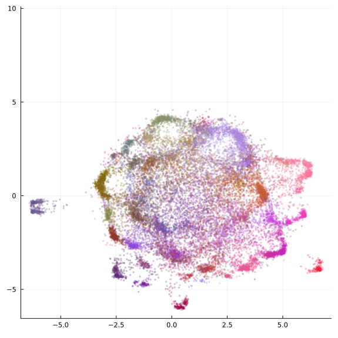

```julia
function normcolors(V)
    min_, max_ = extrema(V)
    V .= (V .- min_) ./ (max_ - min_)
    V .= clamp.(V, 0, 1)
end

normcolors(@view e3[1, :])
normcolors(@view e3[2, :])
normcolors(@view e3[3, :])

C = [RGB(c[1], c[2], c[3]) for c in eachcol(e3)]

X = @view e2[1, :]
Y = @view e2[2, :]
scatter(X, Y, color=C, fmt=:png, alpha=0.2, size=(600, 600), ma=0.3, ms=2, msw=0, label="")

plot!()
```

```julia
dbscanresult = dbscan(e2, 0.035, min_cluster_size=10);
```

[output not shown]

Cluster 20 with 23 elements – showing a small sample

| idfile | name | tbegin | tend | caption |
| --- | --- | --- | --- | --- |
| tres-patines-y-la-tremenda-corte_0018.vtt |  | 14:36.000 | 14:37.000 | Pero acláreme una cosa. |
| tres-patines-y-la-tremenda-corte_0019.vtt |  | 05:22.000 | 05:23.000 | Una cosa que él leyó allí. |
| tres-patines-y-la-tremenda-corte_0037.vtt |  | 05:15.000 | 05:17.000 | Nada, chicos, esta cosa de la vida. |
| tres-patines-y-la-tremenda-corte_0037.vtt |  | 05:17.000 | 05:19.000 | Cosa de la vida, cosa suya. |
| tres-patines-y-la-tremenda-corte_0040.vtt |  | 11:39.000 | 11:40.000 | Bueno, les voy a decir. |
| tres-patines-y-la-tremenda-corte_0040.vtt |  | 11:39.000 | 11:40.000 | Bueno, les voy a decir. |
| tres-patines-y-la-tremenda-corte_0017.vtt |  | 07:00.000 | 07:02.000 | Mire cómo es la cosa. |
| tres-patines-y-la-tremenda-corte_0000.vtt |  | 02:49.000 | 02:50.000 | Pero acláreme una cosa. |
| tres-patines-y-la-tremenda-corte_0018.vtt |  | 14:36.000 | 14:37.000 | Pero acláreme una cosa. |
| tres-patines-y-la-tremenda-corte_0018.vtt |  | 14:36.000 | 14:37.000 | Pero acláreme una cosa. |
| tres-patines-y-la-tremenda-corte_0024.vtt |  | 05:38.000 | 05:40.000 | Que lo traigo para freír |
| tres-patines-y-la-tremenda-corte_0036.vtt |  | 03:30.000 | 03:33.000 | Claro que sí, chico. Si alguien te tiene frito a ti, será ella, chico. |
| tres-patines-y-la-tremenda-corte_0018.vtt |  | 11:27.000 | 11:28.000 | ¿Que fue usted sorprendida |
| tres-patines-y-la-tremenda-corte_0009.vtt |  | 02:14.000 | 02:15.000 | Qué cosa, hombre. |
| tres-patines-y-la-tremenda-corte_0011.vtt |  | 13:08.000 | 13:09.000 | ¿Y no es la misma cosa? |
| tres-patines-y-la-tremenda-corte_0044.vtt |  | 03:36.000 | 03:38.000 | Me le paré a la... en la misma carreta le dije setenta mil horroretos. |
| tres-patines-y-la-tremenda-corte_0018.vtt |  | 11:27.000 | 11:28.000 | ¿Que fue usted sorprendida |
| tres-patines-y-la-tremenda-corte_0044.vtt |  | 11:03.000 | 11:04.000 | ¿Y eso por qué? |
| tres-patines-y-la-tremenda-corte_0040.vtt |  | 05:16.000 | 05:18.000 | Entonces la cosa parece grave. |
| tres-patines-y-la-tremenda-corte_0018.vtt |  | 14:36.000 | 14:37.000 | Pero acláreme una cosa. |

Cluster 41 with 40 elements – showing a small sample

| idfile | name | tbegin | tend | caption |
| --- | --- | --- | --- | --- |
| tres-patines-y-la-tremenda-corte_0000.vtt |  | 05:41.000 | 05:43.000 | Pues cállese entonces, señor. |
| tres-patines-y-la-tremenda-corte_0025.vtt |  | 01:20.440 | 01:23.520 | Que los otros días fue a la playa de Boca Ciega. |
| tres-patines-y-la-tremenda-corte_0028.vtt |  | 14:26.000 | 14:27.000 | ¿Con el cigarro en la boca? |
| tres-patines-y-la-tremenda-corte_0005.vtt |  | 06:47.000 | 06:48.000 | Cállese ahora, trepatín. |
| tres-patines-y-la-tremenda-corte_0045.vtt |  | 06:01.000 | 06:03.000 | Bueno, bueno, cállese la boca. |
| tres-patines-y-la-tremenda-corte_0005.vtt |  | 06:47.000 | 06:48.000 | Cállese ahora, trepatín. |
| tres-patines-y-la-tremenda-corte_0033.vtt |  | 07:21.000 | 07:22.000 | Cállese la boca |
| tres-patines-y-la-tremenda-corte_0005.vtt |  | 06:47.000 | 06:48.000 | Cállese ahora, trepatín. |
| tres-patines-y-la-tremenda-corte_0003.vtt |  | 15:42.320 | 15:43.320 | Cállese la boca. |
| tres-patines-y-la-tremenda-corte_0005.vtt |  | 06:50.000 | 06:51.000 | Cállese la boca. |
| tres-patines-y-la-tremenda-corte_0018.vtt |  | 05:29.000 | 05:31.000 | Cáese la boca. |
| tres-patines-y-la-tremenda-corte_0042.vtt |  | 11:26.000 | 11:27.000 | Con la boca del tógamo. |
| tres-patines-y-la-tremenda-corte_0010.vtt |  | 07:02.000 | 07:04.000 | Mire, cállese usted la boca, cállese la boca. |
| tres-patines-y-la-tremenda-corte_0005.vtt |  | 06:50.000 | 06:51.000 | Cállese la boca. |
| tres-patines-y-la-tremenda-corte_0033.vtt |  | 07:24.000 | 07:26.000 | Cállese la boca |
| tres-patines-y-la-tremenda-corte_0014.vtt |  | 09:07.000 | 09:08.000 | Cállese la boca a usted |
| tres-patines-y-la-tremenda-corte_0005.vtt |  | 06:47.000 | 06:48.000 | Cállese ahora, trepatín. |
| tres-patines-y-la-tremenda-corte_0015.vtt |  | 05:16.000 | 05:17.000 | Cállese la boca. |
| tres-patines-y-la-tremenda-corte_0015.vtt |  | 05:16.000 | 05:17.000 | Cállese la boca. |
| tres-patines-y-la-tremenda-corte_0033.vtt |  | 07:24.000 | 07:26.000 | Cállese la boca |

Cluster 58 with 34 elements – showing a small sample

| idfile | name | tbegin | tend | caption |
| --- | --- | --- | --- | --- |
| tres-patines-y-la-tremenda-corte_0011.vtt |  | 10:03.000 | 10:04.000 | Sí, mire. |
| tres-patines-y-la-tremenda-corte_0011.vtt |  | 10:03.000 | 10:04.000 | Sí, mire. |
| tres-patines-y-la-tremenda-corte_0017.vtt |  | 01:49.000 | 01:50.000 | Sí, sí, sí. Da gusto consultarse. |
| tres-patines-y-la-tremenda-corte_0011.vtt |  | 12:16.000 | 12:18.000 | Sí, una comida redonda. |
| tres-patines-y-la-tremenda-corte_0013.vtt |  | 00:47.000 | 00:48.000 | Sí, estilo Chicago. |
| tres-patines-y-la-tremenda-corte_0044.vtt |  | 13:36.000 | 13:37.000 | Sí, se subió. |
| tres-patines-y-la-tremenda-corte_0044.vtt |  | 13:36.000 | 13:37.000 | Sí, se subió. |
| tres-patines-y-la-tremenda-corte_0031.vtt |  | 01:50.000 | 01:52.000 | Sí, lo felicito. |
| tres-patines-y-la-tremenda-corte_0048.vtt |  | 08:10.000 | 08:11.000 | Sí, el plan de regalos. |
| tres-patines-y-la-tremenda-corte_0019.vtt |  | 07:34.000 | 07:36.000 | Medianoche con pepino, sí. |
| tres-patines-y-la-tremenda-corte_0016.vtt |  | 07:37.160 | 07:38.160 | De los corpulentos, sí. |
| tres-patines-y-la-tremenda-corte_0000.vtt |  | 10:21.000 | 10:22.000 | Sí, hombre, sí. |
| tres-patines-y-la-tremenda-corte_0037.vtt |  | 02:33.000 | 02:35.000 | Sí, filantrópico, sí. |
| tres-patines-y-la-tremenda-corte_0037.vtt |  | 02:33.000 | 02:35.000 | Sí, filantrópico, sí. |
| tres-patines-y-la-tremenda-corte_0020.vtt |  | 05:43.000 | 05:44.000 | Palabra que sí. |
| tres-patines-y-la-tremenda-corte_0019.vtt |  | 07:34.000 | 07:36.000 | Medianoche con pepino, sí. |
| tres-patines-y-la-tremenda-corte_0009.vtt |  | 14:28.000 | 14:30.000 | Sí, es angina de pecho. |
| tres-patines-y-la-tremenda-corte_0006.vtt |  | 04:47.000 | 04:48.000 | Sí, vigente. |
| tres-patines-y-la-tremenda-corte_0031.vtt |  | 09:19.000 | 09:20.000 | Sí, sí. |
| tres-patines-y-la-tremenda-corte_0018.vtt |  | 11:08.000 | 11:09.000 | Sí, tú, sí, tú. |

Cluster 61 with 10 elements

| idfile | name | tbegin | tend | caption |
| --- | --- | --- | --- | --- |
| tres-patines-y-la-tremenda-corte_0000.vtt |  | 13:42.000 | 13:43.000 | Pero eso lo sabe todo el mundo. |
| tres-patines-y-la-tremenda-corte_0009.vtt |  | 11:38.000 | 11:41.000 | Y que lo lleven al matadero a ver si no se pone nervioso. |
| tres-patines-y-la-tremenda-corte_0019.vtt |  | 05:24.000 | 05:28.000 | De no sé qué ley, que tampoco sé quién ha hecho una ley de esa índole. |
| tres-patines-y-la-tremenda-corte_0020.vtt |  | 01:57.000 | 02:00.000 | Vamos a ver usted la estafada, Nananina. |
| tres-patines-y-la-tremenda-corte_0033.vtt |  | 09:17.000 | 09:19.000 | A ver, vamos por parte |
| tres-patines-y-la-tremenda-corte_0039.vtt |  | 04:12.600 | 04:13.900 | Bueno, a ver, explíquemelo. |
| tres-patines-y-la-tremenda-corte_0039.vtt |  | 04:34.300 | 04:36.000 | Bueno, la cuestión del farol. |
| tres-patines-y-la-tremenda-corte_0040.vtt |  | 13:14.000 | 13:15.000 | A ver. |
| tres-patines-y-la-tremenda-corte_0041.vtt |  | 01:27.120 | 01:28.520 | A ver, déjeme ver esa letra. |
| tres-patines-y-la-tremenda-corte_0048.vtt |  | 04:45.000 | 04:46.000 | A ver. |

Cluster 74 with 49 elements – showing a small sample

| idfile | name | tbegin | tend | caption |
| --- | --- | --- | --- | --- |
| tres-patines-y-la-tremenda-corte_0004.vtt |  | 09:35.000 | 09:37.000 | Sí, mamita le tiró el zapato y yo dije, ¡ay! |
| tres-patines-y-la-tremenda-corte_0022.vtt |  | 01:23.000 | 01:24.000 | ¡Presidente! |
| tres-patines-y-la-tremenda-corte_0028.vtt |  | 12:09.000 | 12:10.000 | ¡Miao! |
| tres-patines-y-la-tremenda-corte_0041.vtt |  | 12:39.120 | 12:41.120 | Ah, una gallina cayó eso ¡pam! |
| tres-patines-y-la-tremenda-corte_0028.vtt |  | 11:55.000 | 11:56.000 | Y empezó a gritar ¡Miao! |
| tres-patines-y-la-tremenda-corte_0042.vtt |  | 01:25.000 | 01:27.000 | ¡Ay, el fantasma! |
| tres-patines-y-la-tremenda-corte_0028.vtt |  | 12:09.000 | 12:10.000 | ¡Miao! |
| tres-patines-y-la-tremenda-corte_0006.vtt |  | 01:51.000 | 01:53.000 | ¡A la reja! |
| tres-patines-y-la-tremenda-corte_0007.vtt |  | 02:59.000 | 03:00.000 | ¡Silencio! |
| tres-patines-y-la-tremenda-corte_0004.vtt |  | 09:35.000 | 09:37.000 | Sí, mamita le tiró el zapato y yo dije, ¡ay! |
| tres-patines-y-la-tremenda-corte_0045.vtt |  | 08:00.000 | 08:01.000 | ¡180 días! |
| tres-patines-y-la-tremenda-corte_0002.vtt |  | 11:18.000 | 11:19.000 | ¡Tira eso! |
| tres-patines-y-la-tremenda-corte_0027.vtt |  | 08:11.000 | 08:12.000 | ¡Me morro! |
| tres-patines-y-la-tremenda-corte_0031.vtt |  | 08:50.000 | 08:51.000 | ¡Namba, qué sorpresa! |
| tres-patines-y-la-tremenda-corte_0004.vtt |  | 09:35.000 | 09:37.000 | Sí, mamita le tiró el zapato y yo dije, ¡ay! |
| tres-patines-y-la-tremenda-corte_0036.vtt |  | 08:19.000 | 08:20.000 | ¡Ah! |
| tres-patines-y-la-tremenda-corte_0023.vtt |  | 08:24.600 | 08:25.600 | ¡Y el peso de lucha! |
| tres-patines-y-la-tremenda-corte_0047.vtt |  | 01:52.000 | 01:54.000 | ¡A la vea! |
| tres-patines-y-la-tremenda-corte_0048.vtt |  | 11:18.000 | 11:19.000 | ¡Dígame! |
| tres-patines-y-la-tremenda-corte_0024.vtt |  | 00:02.000 | 00:04.000 | ¡No se olvide que tenéis que pagar mi lechona! |

Cluster 83 with 14 elements

| idfile | name | tbegin | tend | caption |
| --- | --- | --- | --- | --- |
| tres-patines-y-la-tremenda-corte_0001.vtt |  | 07:12.000 | 07:13.000 | ¿A agarrarlo por qué, señor? |
| tres-patines-y-la-tremenda-corte_0014.vtt |  | 14:19.000 | 14:21.000 | No, señor. Eso es fuerza de cara. |
| tres-patines-y-la-tremenda-corte_0015.vtt |  | 04:34.000 | 04:35.000 | Oiganme, señor juez. |
| tres-patines-y-la-tremenda-corte_0018.vtt |  | 01:21.000 | 01:23.000 | Enseguida, señor juez. |
| tres-patines-y-la-tremenda-corte_0019.vtt |  | 01:28.000 | 01:30.000 | Enseguida, señor juez. |
| tres-patines-y-la-tremenda-corte_0020.vtt |  | 01:37.000 | 01:39.000 | Enseguida, señor juez. |
| tres-patines-y-la-tremenda-corte_0025.vtt |  | 08:24.440 | 08:25.040 | Mande, señor juez. |
| tres-patines-y-la-tremenda-corte_0025.vtt |  | 08:30.120 | 08:32.520 | Cuando venía del señor juez, |
| tres-patines-y-la-tremenda-corte_0027.vtt |  | 00:42.000 | 00:43.000 | Pero mire señor juez. |
| tres-patines-y-la-tremenda-corte_0028.vtt |  | 00:56.000 | 01:02.000 | Un escaparate. Pues llámelo complicado en ese escaparaticidio. Enseguida señor juez. |
| tres-patines-y-la-tremenda-corte_0032.vtt |  | 01:01.800 | 01:07.960 | en ese español y sí enseguida señor juez rude cingo caldeiro y escobiña presentes |
| tres-patines-y-la-tremenda-corte_0040.vtt |  | 05:42.000 | 05:43.000 | Claro, señor juez. |
| tres-patines-y-la-tremenda-corte_0045.vtt |  | 00:44.000 | 00:45.000 | Enseguida señor juez. |
| tres-patines-y-la-tremenda-corte_0049.vtt |  | 02:07.000 | 02:14.000 | No, señor, lo único que yo le hice a Rubesindo fue venderle 40 galones de gasolina especial para guagua. |

Cluster 92 with 14 elements

| idfile | name | tbegin | tend | caption |
| --- | --- | --- | --- | --- |
| tres-patines-y-la-tremenda-corte_0001.vtt |  | 12:37.000 | 12:38.000 | De una caída, sí. |
| tres-patines-y-la-tremenda-corte_0005.vtt |  | 02:27.000 | 02:29.000 | No, pero esa sí. |
| tres-patines-y-la-tremenda-corte_0008.vtt |  | 13:25.000 | 13:26.000 | Sí, se dobló. |
| tres-patines-y-la-tremenda-corte_0014.vtt |  | 12:05.000 | 12:07.000 | El vapor, sí. |
| tres-patines-y-la-tremenda-corte_0018.vtt |  | 06:18.000 | 06:19.000 | Municipio, sí. |
| tres-patines-y-la-tremenda-corte_0020.vtt |  | 09:54.000 | 09:55.000 | Sí, mi querido y estimado Dr. |
| tres-patines-y-la-tremenda-corte_0028.vtt |  | 02:41.000 | 02:52.000 | ¿Sí? Hombre, pues si lo supieran en algún lado ya no sería secreto. Entonces nadie sabe que usted es policía. Bueno, sí, lo sabe una persona nada más. |
| tres-patines-y-la-tremenda-corte_0040.vtt |  | 09:04.000 | 09:05.000 | Sí, vale. |
| tres-patines-y-la-tremenda-corte_0044.vtt |  | 04:37.000 | 04:38.000 | Ahora, que eso sí. |
| tres-patines-y-la-tremenda-corte_0044.vtt |  | 06:43.000 | 06:44.000 | Sí, sí. |
| tres-patines-y-la-tremenda-corte_0044.vtt |  | 09:31.000 | 09:32.000 | Sí, sí. |
| tres-patines-y-la-tremenda-corte_0045.vtt |  | 07:56.000 | 07:58.000 | Sí, pero lo que no puedes comer hierba. |
| tres-patines-y-la-tremenda-corte_0049.vtt |  | 12:42.000 | 12:44.000 | De la cuenca sur, sí. |
| tres-patines-y-la-tremenda-corte_0050.vtt |  | 10:56.160 | 10:57.160 | Si está de frente a frente. |

Cluster 95 with 24 elements – showing a small sample

| idfile | name | tbegin | tend | caption |
| --- | --- | --- | --- | --- |
| tres-patines-y-la-tremenda-corte_0009.vtt |  | 00:00.000 | 00:12.000 | Audiencia publica, el tremendo juez de la tremenda corte va a resolver un tremendo caso. |
| tres-patines-y-la-tremenda-corte_0039.vtt |  | 10:31.400 | 10:35.900 | Bueno, no, porque con el boca debajo los pulmones quedan apretados, tú sabes. |
| tres-patines-y-la-tremenda-corte_0031.vtt |  | 07:42.000 | 07:44.000 | Yo no tengo trapitos sucios ninguno para que se entere. |
| tres-patines-y-la-tremenda-corte_0031.vtt |  | 07:42.000 | 07:44.000 | Yo no tengo trapitos sucios ninguno para que se entere. |
| tres-patines-y-la-tremenda-corte_0012.vtt |  | 11:50.960 | 11:52.960 | ropa en la escalera de ese edificio. |
| tres-patines-y-la-tremenda-corte_0039.vtt |  | 10:31.400 | 10:35.900 | Bueno, no, porque con el boca debajo los pulmones quedan apretados, tú sabes. |
| tres-patines-y-la-tremenda-corte_0012.vtt |  | 11:50.960 | 11:52.960 | ropa en la escalera de ese edificio. |
| tres-patines-y-la-tremenda-corte_0023.vtt |  | 12:07.600 | 12:09.600 | Porque me han dicho que yo tengo condiciones para eso. |
| tres-patines-y-la-tremenda-corte_0023.vtt |  | 12:07.600 | 12:09.600 | Porque me han dicho que yo tengo condiciones para eso. |
| tres-patines-y-la-tremenda-corte_0035.vtt |  | 08:06.000 | 08:09.000 | Pero sé que se venden así porque los he comprado cuando era chiquito. |
| tres-patines-y-la-tremenda-corte_0045.vtt |  | 05:14.000 | 05:15.000 | De una mate mango. |
| tres-patines-y-la-tremenda-corte_0010.vtt |  | 02:49.000 | 02:52.000 | mamita puso una cazuela sobre la mesa del comedor. |
| tres-patines-y-la-tremenda-corte_0021.vtt |  | 06:55.000 | 06:59.000 | Sí, rudecido le dice cuál es la izquierda y entonces yo le digo cuál es la derecha. |
| tres-patines-y-la-tremenda-corte_0039.vtt |  | 10:31.400 | 10:35.900 | Bueno, no, porque con el boca debajo los pulmones quedan apretados, tú sabes. |
| tres-patines-y-la-tremenda-corte_0003.vtt |  | 09:56.700 | 10:04.620 | motoneta no a pie llevaba su cajóncito igual que el mismo el cajón del limpia |
| tres-patines-y-la-tremenda-corte_0036.vtt |  | 06:40.000 | 06:41.000 | Su mamita baila merengue. |
| tres-patines-y-la-tremenda-corte_0045.vtt |  | 05:14.000 | 05:15.000 | De una mate mango. |
| tres-patines-y-la-tremenda-corte_0017.vtt |  | 11:32.000 | 11:38.000 | Mientras en el mundo haya una ganzúa y una pata de cabra, el hijo de mamita nunca pasará hambre, para que te enteres. |
| tres-patines-y-la-tremenda-corte_0017.vtt |  | 11:32.000 | 11:38.000 | Mientras en el mundo haya una ganzúa y una pata de cabra, el hijo de mamita nunca pasará hambre, para que te enteres. |
| tres-patines-y-la-tremenda-corte_0036.vtt |  | 06:40.000 | 06:41.000 | Su mamita baila merengue. |

Cluster 109 with 18 elements

| idfile | name | tbegin | tend | caption |
| --- | --- | --- | --- | --- |
| tres-patines-y-la-tremenda-corte_0002.vtt |  | 13:46.000 | 13:53.000 | Yo te dije que me esperase unas semanas hasta que yo encontrase otro terrenito vacío para mudar el chaleche. |
| tres-patines-y-la-tremenda-corte_0004.vtt |  | 03:01.000 | 03:03.000 | ¿Y entonces por qué no la suprimen, chico? |
| tres-patines-y-la-tremenda-corte_0007.vtt |  | 06:48.000 | 06:51.000 | debe al lavandero, debe al carnicero. |
| tres-patines-y-la-tremenda-corte_0010.vtt |  | 05:45.000 | 05:46.000 | ¿Y eso por qué, chico? |
| tres-patines-y-la-tremenda-corte_0010.vtt |  | 11:16.000 | 11:19.000 | que cuánto le cobraba por dar un paseo en máquina. |
| tres-patines-y-la-tremenda-corte_0010.vtt |  | 14:46.000 | 14:48.000 | Yo le dije, entonces, ¿hora y qué hora es? |
| tres-patines-y-la-tremenda-corte_0011.vtt |  | 06:26.000 | 06:28.000 | Y saliendo de San Diego de los Baños por esa vereda |
| tres-patines-y-la-tremenda-corte_0012.vtt |  | 10:27.640 | 10:29.640 | ¿Por qué? Porque cada vez que le tocan a la puerta |
| tres-patines-y-la-tremenda-corte_0013.vtt |  | 13:21.000 | 13:25.000 | En vista de eso, pues yo hablé por el revolver, todo el mundo salió corriendo. |
| tres-patines-y-la-tremenda-corte_0014.vtt |  | 07:43.000 | 07:44.000 | Bueno, por eso |
| tres-patines-y-la-tremenda-corte_0029.vtt |  | 11:00.000 | 11:01.000 | ¿Por qué, chico? |
| tres-patines-y-la-tremenda-corte_0031.vtt |  | 05:54.000 | 05:56.000 | por incitar a la autoridad a jugar al prohibido. |
| tres-patines-y-la-tremenda-corte_0031.vtt |  | 10:55.000 | 10:56.000 | Yo no entiendo ni media palabra. |
| tres-patines-y-la-tremenda-corte_0032.vtt |  | 12:42.720 | 12:47.880 | pagado por él porque 200 pesos por ese puesto no iba a encontrar yo nadie que me lo diera pero |
| tres-patines-y-la-tremenda-corte_0035.vtt |  | 03:24.000 | 03:26.000 | ¿Y entonces por qué te estoy contestando yo? |
| tres-patines-y-la-tremenda-corte_0041.vtt |  | 10:46.120 | 10:48.120 | Pero es que rudeciendo dice, |
| tres-patines-y-la-tremenda-corte_0043.vtt |  | 11:57.000 | 12:02.000 | Pues antes de irse a pelar, cuando estuvo en casa, cargó el gato todo el tiempo, oiga, |
| tres-patines-y-la-tremenda-corte_0047.vtt |  | 02:28.000 | 02:32.000 | Y cuando se enteró de que venía un ciclón se puso muy nerviosa. |

Cluster 110 with 14 elements

| idfile | name | tbegin | tend | caption |
| --- | --- | --- | --- | --- |
| tres-patines-y-la-tremenda-corte_0002.vtt |  | 13:53.000 | 13:55.000 | ¿Cuántas semanas le pidió que lo esperase? |
| tres-patines-y-la-tremenda-corte_0011.vtt |  | 08:25.000 | 08:26.000 | ¿Le gusta? |
| tres-patines-y-la-tremenda-corte_0014.vtt |  | 11:07.000 | 11:08.000 | No, siempre de qué |
| tres-patines-y-la-tremenda-corte_0015.vtt |  | 11:38.000 | 11:39.000 | ¿Usted cree? |
| tres-patines-y-la-tremenda-corte_0016.vtt |  | 09:07.960 | 09:09.360 | ¿Y de lo de sudorra? |
| tres-patines-y-la-tremenda-corte_0019.vtt |  | 08:33.000 | 08:35.000 | ¿usted se quiere reír en esta |
| tres-patines-y-la-tremenda-corte_0037.vtt |  | 13:29.000 | 13:30.000 | ¿Dónde? Contésteme. |
| tres-patines-y-la-tremenda-corte_0039.vtt |  | 06:20.300 | 06:21.100 | ¿Seguro? |
| tres-patines-y-la-tremenda-corte_0040.vtt |  | 07:12.000 | 07:13.000 | ¿En vez de lo cual? |
| tres-patines-y-la-tremenda-corte_0042.vtt |  | 07:24.000 | 07:25.000 | ¿Y qué hizo usted, Albert? |
| tres-patines-y-la-tremenda-corte_0044.vtt |  | 09:04.000 | 09:06.000 | Usted tiene que pagarle su carro, ¿qué país? |
| tres-patines-y-la-tremenda-corte_0044.vtt |  | 10:16.000 | 10:18.000 | Si viene a cruzar ahora, él cerró los ojos. |
| tres-patines-y-la-tremenda-corte_0045.vtt |  | 08:09.000 | 08:10.000 | De nada. |
| tres-patines-y-la-tremenda-corte_0050.vtt |  | 04:00.000 | 04:01.000 | ¿Qué pasó? |

Cluster 115 with 17 elements

| idfile | name | tbegin | tend | caption |
| --- | --- | --- | --- | --- |
| tres-patines-y-la-tremenda-corte_0003.vtt |  | 00:51.560 | 00:54.600 | y la y para el hígado no no un momento |
| tres-patines-y-la-tremenda-corte_0005.vtt |  | 03:30.000 | 03:32.000 | Sinforosa no existe. |
| tres-patines-y-la-tremenda-corte_0006.vtt |  | 11:37.000 | 11:39.000 | Por la chimenea no podemos entrar porque no cabemos. |
| tres-patines-y-la-tremenda-corte_0009.vtt |  | 06:47.000 | 06:48.000 | Momento. |
| tres-patines-y-la-tremenda-corte_0009.vtt |  | 12:06.000 | 12:07.000 | Rubesindo. |
| tres-patines-y-la-tremenda-corte_0011.vtt |  | 10:38.000 | 10:39.000 | No sé. |
| tres-patines-y-la-tremenda-corte_0014.vtt |  | 10:44.000 | 10:45.000 | No |
| tres-patines-y-la-tremenda-corte_0023.vtt |  | 09:47.600 | 09:48.600 | Que yo no enseño. |
| tres-patines-y-la-tremenda-corte_0028.vtt |  | 02:34.000 | 02:41.000 | No, porque en la jefatura no saben que yo soy policía. ¿Cómo que no lo sabes? Claro que no, no le estoy diciendo que soy un policía secreto. |
| tres-patines-y-la-tremenda-corte_0032.vtt |  | 07:22.680 | 07:28.680 | domingo y si no no trabajo pero entre miré levantarse tarde bañarme a almorzar dormir la |
| tres-patines-y-la-tremenda-corte_0033.vtt |  | 06:28.000 | 06:29.000 | No |
| tres-patines-y-la-tremenda-corte_0044.vtt |  | 06:52.000 | 06:53.000 | No debería. |
| tres-patines-y-la-tremenda-corte_0044.vtt |  | 09:59.000 | 10:00.000 | Pero no paró. |
| tres-patines-y-la-tremenda-corte_0046.vtt |  | 02:52.000 | 02:55.000 | Y no falla nunca eso no falla nunca |
| tres-patines-y-la-tremenda-corte_0046.vtt |  | 09:16.000 | 09:18.000 | No no no un pollito |
| tres-patines-y-la-tremenda-corte_0046.vtt |  | 09:26.000 | 09:27.000 | No era pollito no |
| tres-patines-y-la-tremenda-corte_0046.vtt |  | 09:28.000 | 09:29.000 | No no no |

Cluster 125 with 10 elements

| idfile | name | tbegin | tend | caption |
| --- | --- | --- | --- | --- |
| tres-patines-y-la-tremenda-corte_0003.vtt |  | 15:22.320 | 15:23.320 | y comerme un potaje de garbanzos. |
| tres-patines-y-la-tremenda-corte_0010.vtt |  | 08:18.000 | 08:22.000 | Usted me tiene que pagar cuatro horas menos cinco minutos. |
| tres-patines-y-la-tremenda-corte_0010.vtt |  | 12:05.000 | 12:08.000 | yo lo afinco aquí con multas de cinco y de cinco y de cinco |
| tres-patines-y-la-tremenda-corte_0011.vtt |  | 09:11.000 | 09:12.000 | ¿Usted le invitó? |
| tres-patines-y-la-tremenda-corte_0017.vtt |  | 04:21.000 | 04:22.000 | De 8 onzas. |
| tres-patines-y-la-tremenda-corte_0017.vtt |  | 04:54.000 | 04:57.000 | Que como el valor de una libra son 16 onzas, |
| tres-patines-y-la-tremenda-corte_0030.vtt |  | 11:46.440 | 11:48.440 | y me dijo que por 50 pesos, |
| tres-patines-y-la-tremenda-corte_0033.vtt |  | 05:43.000 | 05:44.000 | Un sillón de barbero |
| tres-patines-y-la-tremenda-corte_0035.vtt |  | 08:51.000 | 08:52.000 | 1918. |
| tres-patines-y-la-tremenda-corte_0036.vtt |  | 08:47.000 | 08:48.000 | Siga usted, Anamina. |

Cluster 128 with 31 elements – showing a small sample

| idfile | name | tbegin | tend | caption |
| --- | --- | --- | --- | --- |
| tres-patines-y-la-tremenda-corte_0005.vtt |  | 08:22.000 | 08:24.000 | Diez pesos de multa por esa aclaración. |
| tres-patines-y-la-tremenda-corte_0019.vtt |  | 09:20.000 | 09:22.000 | Ponle veinte pesos de multa, secretario. |
| tres-patines-y-la-tremenda-corte_0040.vtt |  | 06:17.000 | 06:19.000 | No me costó veinte kilos la macha. |
| tres-patines-y-la-tremenda-corte_0047.vtt |  | 04:45.000 | 04:48.000 | Póngale otro 10 pesos de multa, secretario. |
| tres-patines-y-la-tremenda-corte_0017.vtt |  | 04:24.000 | 04:27.000 | Pongale 50 pesos de multa, rudecido, y que le decomisen la pesa. |
| tres-patines-y-la-tremenda-corte_0040.vtt |  | 06:17.000 | 06:19.000 | No me costó veinte kilos la macha. |
| tres-patines-y-la-tremenda-corte_0048.vtt |  | 10:17.000 | 10:19.000 | Póngale cinco pesos más de multa a esta extranjera. |
| tres-patines-y-la-tremenda-corte_0045.vtt |  | 07:53.000 | 07:54.000 | Veinte pesos más de multa. |
| tres-patines-y-la-tremenda-corte_0033.vtt |  | 03:24.000 | 03:27.000 | 10 pesos de multa por insistir |
| tres-patines-y-la-tremenda-corte_0023.vtt |  | 12:51.600 | 12:54.600 | fuimos a ver a tres patines para que nos los enseñara los dos. |
| tres-patines-y-la-tremenda-corte_0043.vtt |  | 09:58.000 | 10:00.000 | Cincuenta pesos de multa. |
| tres-patines-y-la-tremenda-corte_0050.vtt |  | 08:19.000 | 08:20.000 | Póngale 50 más. |
| tres-patines-y-la-tremenda-corte_0019.vtt |  | 11:36.000 | 11:38.000 | Póngale 23 pesos de multa, secretario. |
| tres-patines-y-la-tremenda-corte_0019.vtt |  | 11:36.000 | 11:38.000 | Póngale 23 pesos de multa, secretario. |
| tres-patines-y-la-tremenda-corte_0043.vtt |  | 09:58.000 | 10:00.000 | Cincuenta pesos de multa. |
| tres-patines-y-la-tremenda-corte_0017.vtt |  | 04:24.000 | 04:27.000 | Pongale 50 pesos de multa, rudecido, y que le decomisen la pesa. |
| tres-patines-y-la-tremenda-corte_0005.vtt |  | 01:38.000 | 01:39.000 | Póngale dos pesos de multa. |
| tres-patines-y-la-tremenda-corte_0047.vtt |  | 04:45.000 | 04:48.000 | Póngale otro 10 pesos de multa, secretario. |
| tres-patines-y-la-tremenda-corte_0023.vtt |  | 12:51.600 | 12:54.600 | fuimos a ver a tres patines para que nos los enseñara los dos. |
| tres-patines-y-la-tremenda-corte_0011.vtt |  | 06:07.000 | 06:09.000 | Pongale diez pesos de multa. |

Cluster 129 with 12 elements

| idfile | name | tbegin | tend | caption |
| --- | --- | --- | --- | --- |
| tres-patines-y-la-tremenda-corte_0004.vtt |  | 08:10.000 | 08:11.000 | Palabra que no, chico. |
| tres-patines-y-la-tremenda-corte_0005.vtt |  | 07:33.000 | 07:34.000 | Pues no se me equivoca más. |
| tres-patines-y-la-tremenda-corte_0005.vtt |  | 08:32.000 | 08:33.000 | Me lo pusiste, chico. |
| tres-patines-y-la-tremenda-corte_0005.vtt |  | 14:52.000 | 14:54.000 | carne a la dama, chico. |
| tres-patines-y-la-tremenda-corte_0008.vtt |  | 12:08.000 | 12:10.000 | En el centro gallego, chico. |
| tres-patines-y-la-tremenda-corte_0013.vtt |  | 12:59.000 | 13:01.000 | Chico, oye, ¿se permite qué, chico? |
| tres-patines-y-la-tremenda-corte_0016.vtt |  | 05:32.560 | 05:34.760 | No seas pócrita, chico. |
| tres-patines-y-la-tremenda-corte_0020.vtt |  | 08:53.000 | 08:54.000 | Hombre, en el comentario, chico. |
| tres-patines-y-la-tremenda-corte_0021.vtt |  | 04:39.000 | 04:41.000 | Óyeme, de ninguna manera, chico. |
| tres-patines-y-la-tremenda-corte_0033.vtt |  | 11:54.000 | 11:56.000 | Sino los peludos que van a pelarse, chico |
| tres-patines-y-la-tremenda-corte_0042.vtt |  | 01:34.000 | 01:36.500 | No, chico. Yo soy el acusado nomás. |
| tres-patines-y-la-tremenda-corte_0042.vtt |  | 09:14.000 | 09:15.000 | También, chico. |

Cluster 149 with 14 elements

| idfile | name | tbegin | tend | caption |
| --- | --- | --- | --- | --- |
| tres-patines-y-la-tremenda-corte_0007.vtt |  | 00:42.000 | 00:43.000 | Primero me pongo una coraza. |
| tres-patines-y-la-tremenda-corte_0013.vtt |  | 04:45.000 | 04:53.000 | Sí, yo le dije que pusiéramos uno de esos vestidos en la viriera con un letrerito que dijera, lo mejor en encaje con cola. |
| tres-patines-y-la-tremenda-corte_0020.vtt |  | 02:48.000 | 02:50.000 | Me dijo usted que estaba colocada en casa de un médico. |
| tres-patines-y-la-tremenda-corte_0025.vtt |  | 04:46.520 | 04:50.240 | Nada, pues que ahora quedó tan apeñuscado allá adentro |
| tres-patines-y-la-tremenda-corte_0026.vtt |  | 13:23.000 | 13:25.000 | se despidió de nosotros, |
| tres-patines-y-la-tremenda-corte_0030.vtt |  | 05:26.440 | 05:28.440 | en el transcurso del cual |
| tres-patines-y-la-tremenda-corte_0030.vtt |  | 13:02.440 | 13:04.440 | O sea que mamita conseguía |
| tres-patines-y-la-tremenda-corte_0040.vtt |  | 00:45.000 | 00:52.000 | Que le dijera que sí, que está dispuesta a ir al cine con usted, pero acompañada por su papá y su mamá. |
| tres-patines-y-la-tremenda-corte_0041.vtt |  | 07:38.120 | 07:40.120 | que traía acusado a ese sujeto. |
| tres-patines-y-la-tremenda-corte_0044.vtt |  | 02:19.000 | 02:22.000 | El día ese yo salí fatal del paradero, ¿oíste? |
| tres-patines-y-la-tremenda-corte_0045.vtt |  | 09:52.000 | 09:55.000 | No, señora, yo no ni me ocupé más de las reses para nada. |
| tres-patines-y-la-tremenda-corte_0049.vtt |  | 12:44.000 | 12:47.000 | Bueno, pues agua lo es de todas maneras, ¿me entiende? |
| tres-patines-y-la-tremenda-corte_0050.vtt |  | 11:47.920 | 11:52.120 | patines y en dos meses nada más que estuvieron en la finca me acabaron con ella. |
| tres-patines-y-la-tremenda-corte_0050.vtt |  | 13:14.520 | 13:18.800 | El ñame y los buñatos, eso, el melón y el tronco de yuca honoris causa, ese que ustedes |

Cluster 155 with 16 elements

| idfile | name | tbegin | tend | caption |
| --- | --- | --- | --- | --- |
| tres-patines-y-la-tremenda-corte_0008.vtt |  | 05:33.000 | 05:35.000 | Vaya, por Dios. |
| tres-patines-y-la-tremenda-corte_0013.vtt |  | 11:33.000 | 11:35.000 | Anote eso, secretario, de modo... |
| tres-patines-y-la-tremenda-corte_0015.vtt |  | 03:25.000 | 03:28.000 | Pague en efectivo, vaya a la cárcel. |
| tres-patines-y-la-tremenda-corte_0017.vtt |  | 04:43.000 | 04:44.000 | Verá usted, doctor. |
| tres-patines-y-la-tremenda-corte_0018.vtt |  | 07:35.000 | 07:36.000 | Hombre, por Dios. |
| tres-patines-y-la-tremenda-corte_0030.vtt |  | 03:55.240 | 03:57.240 | No se preocupe, Rudecindo, que se le hará justicia. |
| tres-patines-y-la-tremenda-corte_0033.vtt |  | 10:31.000 | 10:32.000 | Dito Dios |
| tres-patines-y-la-tremenda-corte_0035.vtt |  | 02:18.000 | 02:19.000 | para que vaya comiendo. |
| tres-patines-y-la-tremenda-corte_0038.vtt |  | 03:53.000 | 03:56.000 | Hombre, por Dios, parece hasta mentira |
| tres-patines-y-la-tremenda-corte_0038.vtt |  | 04:59.000 | 05:01.000 | Hombre, por Dios |
| tres-patines-y-la-tremenda-corte_0039.vtt |  | 04:08.900 | 04:09.900 | ¿Vista desde dónde? |
| tres-patines-y-la-tremenda-corte_0039.vtt |  | 13:04.400 | 13:06.400 | No, Trespatines, hombre. |
| tres-patines-y-la-tremenda-corte_0042.vtt |  | 10:22.000 | 10:25.000 | De Máximo Plan. |
| tres-patines-y-la-tremenda-corte_0047.vtt |  | 00:39.000 | 00:41.000 | Vaya, por Dios lo siento señor juez. |
| tres-patines-y-la-tremenda-corte_0048.vtt |  | 09:00.000 | 09:01.000 | Pero... |
| tres-patines-y-la-tremenda-corte_0050.vtt |  | 00:46.000 | 00:48.000 | Vaya por Dios, pobrecita ella. |

Cluster 170 with 43 elements – showing a small sample

| idfile | name | tbegin | tend | caption |
| --- | --- | --- | --- | --- |
| tres-patines-y-la-tremenda-corte_0034.vtt |  | 01:51.000 | 01:52.000 | ¿Cómo lo hicieron? |
| tres-patines-y-la-tremenda-corte_0034.vtt |  | 01:42.000 | 01:43.000 | ¿Cómo lo hicieron? |
| tres-patines-y-la-tremenda-corte_0034.vtt |  | 01:42.000 | 01:43.000 | ¿Cómo lo hicieron? |
| tres-patines-y-la-tremenda-corte_0034.vtt |  | 02:15.000 | 02:16.000 | ¿Cómo lo hicieron? |
| tres-patines-y-la-tremenda-corte_0034.vtt |  | 04:08.000 | 04:09.000 | ¿Cómo lo hicieron? |
| tres-patines-y-la-tremenda-corte_0034.vtt |  | 02:16.000 | 02:17.000 | ¿Cómo lo hicieron? |
| tres-patines-y-la-tremenda-corte_0034.vtt |  | 00:31.000 | 00:32.000 | ¿Cómo lo hicieron? |
| tres-patines-y-la-tremenda-corte_0034.vtt |  | 00:21.000 | 00:22.000 | ¿Cómo lo hicieron? |
| tres-patines-y-la-tremenda-corte_0034.vtt |  | 02:16.000 | 02:17.000 | ¿Cómo lo hicieron? |
| tres-patines-y-la-tremenda-corte_0034.vtt |  | 02:16.000 | 02:17.000 | ¿Cómo lo hicieron? |
| tres-patines-y-la-tremenda-corte_0034.vtt |  | 03:51.000 | 03:52.000 | ¿Cómo lo hicieron? |
| tres-patines-y-la-tremenda-corte_0034.vtt |  | 01:14.000 | 01:15.000 | ¿Cómo lo hicieron? |
| tres-patines-y-la-tremenda-corte_0034.vtt |  | 02:08.000 | 02:09.000 | ¿Cómo lo hicieron? |
| tres-patines-y-la-tremenda-corte_0034.vtt |  | 02:33.000 | 02:34.000 | ¿Cómo lo hicieron? |
| tres-patines-y-la-tremenda-corte_0034.vtt |  | 03:51.000 | 03:52.000 | ¿Cómo lo hicieron? |
| tres-patines-y-la-tremenda-corte_0014.vtt |  | 10:40.000 | 10:41.000 | Lo denunciaron |
| tres-patines-y-la-tremenda-corte_0034.vtt |  | 04:20.000 | 04:21.000 | ¿Cómo lo hicieron? |
| tres-patines-y-la-tremenda-corte_0034.vtt |  | 03:23.000 | 03:24.000 | ¿Cómo lo hicieron? |
| tres-patines-y-la-tremenda-corte_0034.vtt |  | 04:20.000 | 04:21.000 | ¿Cómo lo hicieron? |
| tres-patines-y-la-tremenda-corte_0034.vtt |  | 03:02.000 | 03:03.000 | ¿Cómo lo hicieron? |

Cluster 174 with 17 elements

| idfile | name | tbegin | tend | caption |
| --- | --- | --- | --- | --- |
| tres-patines-y-la-tremenda-corte_0034.vtt |  | 00:23.000 | 00:24.000 | ¿Cómo lo hicieron? |
| tres-patines-y-la-tremenda-corte_0034.vtt |  | 00:33.000 | 00:34.000 | ¿Cómo lo hicieron? |
| tres-patines-y-la-tremenda-corte_0034.vtt |  | 00:49.000 | 00:50.000 | ¿Cómo lo hicieron? |
| tres-patines-y-la-tremenda-corte_0034.vtt |  | 00:51.000 | 00:52.000 | ¿Cómo lo hicieron? |
| tres-patines-y-la-tremenda-corte_0034.vtt |  | 00:52.000 | 00:53.000 | ¿Cómo lo hicieron? |
| tres-patines-y-la-tremenda-corte_0034.vtt |  | 01:18.000 | 01:19.000 | ¿Cómo lo hicieron? |
| tres-patines-y-la-tremenda-corte_0034.vtt |  | 01:22.000 | 01:23.000 | ¿Cómo lo hicieron? |
| tres-patines-y-la-tremenda-corte_0034.vtt |  | 02:21.000 | 02:22.000 | ¿Cómo lo hicieron? |
| tres-patines-y-la-tremenda-corte_0034.vtt |  | 02:24.000 | 02:25.000 | ¿Cómo lo hicieron? |
| tres-patines-y-la-tremenda-corte_0034.vtt |  | 02:50.000 | 02:51.000 | ¿Cómo lo hicieron? |
| tres-patines-y-la-tremenda-corte_0034.vtt |  | 03:01.000 | 03:02.000 | ¿Cómo lo hicieron? |
| tres-patines-y-la-tremenda-corte_0034.vtt |  | 03:13.000 | 03:14.000 | ¿Cómo lo hicieron? |
| tres-patines-y-la-tremenda-corte_0034.vtt |  | 03:14.000 | 03:15.000 | ¿Cómo lo hicieron? |
| tres-patines-y-la-tremenda-corte_0034.vtt |  | 03:46.000 | 03:47.000 | ¿Cómo lo hicieron? |
| tres-patines-y-la-tremenda-corte_0034.vtt |  | 04:10.000 | 04:11.000 | ¿Cómo lo hicieron? |
| tres-patines-y-la-tremenda-corte_0034.vtt |  | 04:14.000 | 04:15.000 | ¿Cómo lo hicieron? |
| tres-patines-y-la-tremenda-corte_0034.vtt |  | 04:26.000 | 04:27.000 | ¿Cómo lo hicieron? |

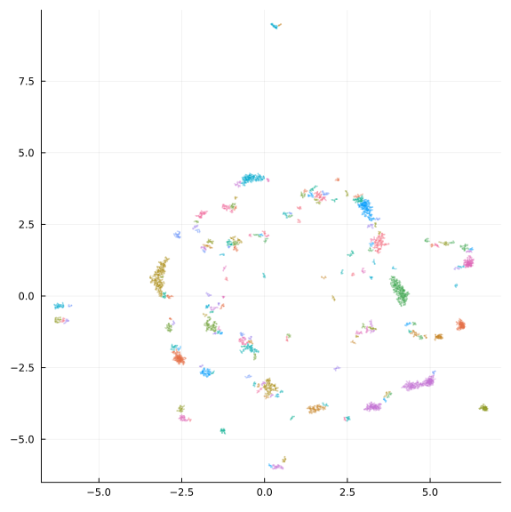

```julia
display(length(dbscanresult.clusters))

plot()
for (i, c) in enumerate(dbscanresult.clusters)
    X = @view e2[1, c.core_indices]
    Y = @view e2[2, c.core_indices]
    scatter!(X, Y, c=:auto, fmt=:png, size=(600, 600), ma=0.3, a=0.3, ms=1, msw=0, label="")
    if rand() < 0.1  # just to show some examples
        X = c.core_indices
        sampled = ""
        if length(X) > 20
            sampled = "-- showing a small sample"
            X = rand(X, 20)
        end
        display(Markdown.parse("## Cluster $i with $(length(c.core_indices)) elements $sampled"))
        display(latexify(D[X, :], env=:mdtable, latex=false))
    end
end

plot!()
```

## Environment and dependencies

```
Julia Version 1.10.10
Commit 95f30e51f41 (2025-06-27 09:51 UTC)
Build Info:
  Official https://julialang.org/ release
Platform Info:
  OS: Linux (x86_64-linux-gnu)
  CPU: 64 × Intel(R) Xeon(R) Silver 4216 CPU @ 2.10GHz
  WORD_SIZE: 64
  LIBM: libopenlibm
  LLVM: libLLVM-15.0.7 (ORCJIT, cascadelake)
Threads: 64 default, 0 interactive, 32 GC (on 64 virtual cores)
Environment:
  JULIA_NUM_THREADS = auto
  JULIA_PROJECT = .
  JULIA_LOAD_PATH = @:@stdlib
Status `~/Research/SimilaritySearchDemos/Project.toml`
  [aaaa29a8] Clustering v0.15.8
  [944b1d66] CodecZlib v0.7.8
  [a93c6f00] DataFrames v1.8.0
  [c5bfea45] Embeddings v0.4.6
  [f67ccb44] HDF5 v0.17.2
  [b20bd276] InvertedFiles v0.8.1
  [682c06a0] JSON v0.21.4
  [23fbe1c1] Latexify v0.16.10
  [eb30cadb] MLDatasets v0.7.18
  [06eb3307] ManifoldLearning v0.9.0
⌃ [ca7969ec] PlotlyLight v0.11.0
  [91a5bcdd] Plots v1.40.20
  [27ebfcd6] Primes v0.5.7
  [ca7ab67e] SimSearchManifoldLearning v0.3.1
  [053f045d] SimilaritySearch v0.13.0
⌅ [2913bbd2] StatsBase v0.33.21
  [f3b207a7] StatsPlots v0.15.7
  [7f6f6c8a] TextSearch v0.19.6
Info Packages marked with ⌃ and ⌅ have new versions available. Those with ⌃ may be upgradable, but those with ⌅ are restricted by compatibility constraints from upgrading. To see why use `status --outdated`
```